# Infer: a package for tidy Statistical Inference

This blog post is my attempt to process and expand on an excellent talk delivered by Andrew Bray at rstudio::conf2018. [The slides (PDF) from Andrew’s presentation can be found at this github link](https://github.com/andrewpbray/talks/blob/master/2018/infer-rstudioconf-2018.pdf).

From Infer’s [homepage](http://infer.netlify.com/):

> The objective of this package is to perform statistical inference using an expressive statistical grammar that coheres with the tidyverse design framework.

Let’s see how that’s done. First we install `infer` and load it into our environment.

```r
# install.packages("infer")
library(infer)
library(cowplot) # for nice plots
```

Infer is supposed to play well within the tidyverse, so we load that too, along with some data from the [General Social Survey](http://gss.norc.org/). In this dataset, we see the diversity of information collected.

```r
library(tidyverse)
load(url("http://bit.ly/2E65g15")) # loads some data from the general social survey
names(gss)
```

```
##  [1] "id"       "year"     "age"      "class"    "degree"   "sex"
##  [7] "marital"  "race"     "region"   "partyid"  "happy"    "relig"
## [13] "cappun"   "finalter" "natspac"  "natarms"  "conclerg" "confed"
## [19] "conpress" "conjudge" "consci"   "conlegis" "zodiac"   "oversamp"
## [25] "postlife" "party"    "space"    "NASA"
```

## Question: Is funding for space exploration (NASA) a partisan issue?

Let’s start by looking at responses to the question: **“Do you think funding for space exploration is too little, about right, or too much?”**

```r
gss %>% select(party, NASA)
```

```
## # A tibble: 149 x 2
##     party        NASA
##    <fctr>      <fctr>
##  1    Ind  TOO LITTLE
##  2    Ind ABOUT RIGHT
##  3    Dem ABOUT RIGHT
##  4    Ind  TOO LITTLE
##  5    Ind    TOO MUCH
##  6    Ind  TOO LITTLE
##  7    Ind ABOUT RIGHT
##  8    Dem ABOUT RIGHT
##  9    Dem  TOO LITTLE
## 10    Ind  TOO LITTLE
## # ... with 139 more rows
```

We see that people can either select *too little*, *about right*, or *too much*. We can visualize this pretty easily:

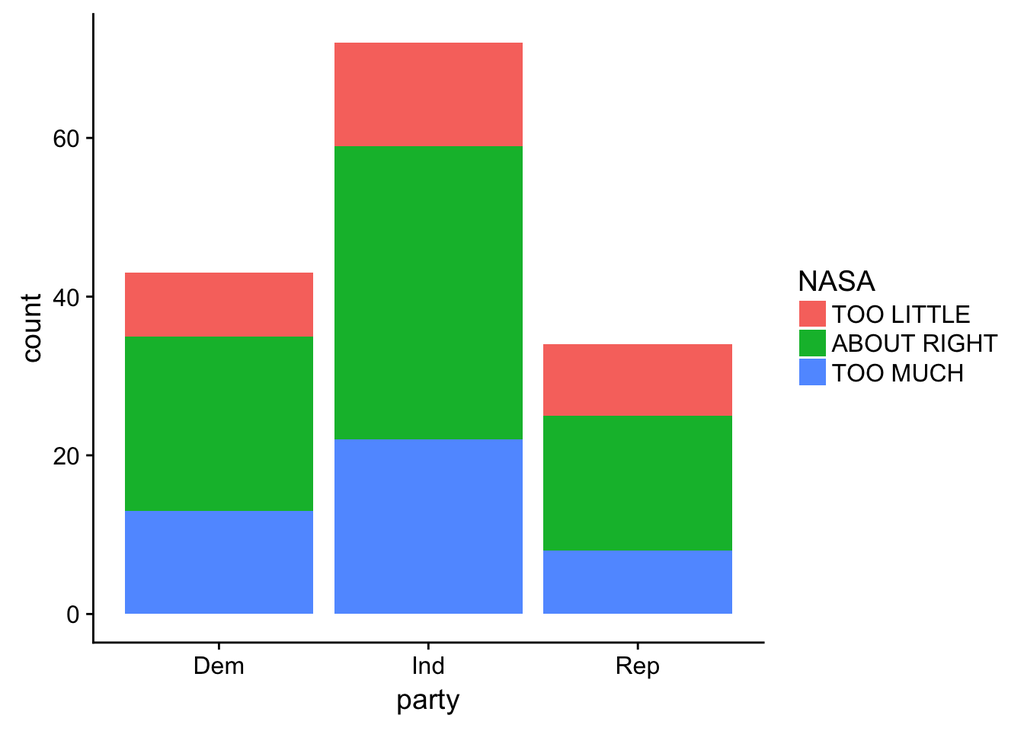

```r
gss %>%
  select(party, NASA) %>%
  ggplot(aes(x=party, fill = NASA)) +
  geom_bar()
```

Count data can be misleading when we’re looking for trends between categorical variables within groups, so let’s normalize within-group-percentages with a `position = "fill"` argument in `geom_bar()`.

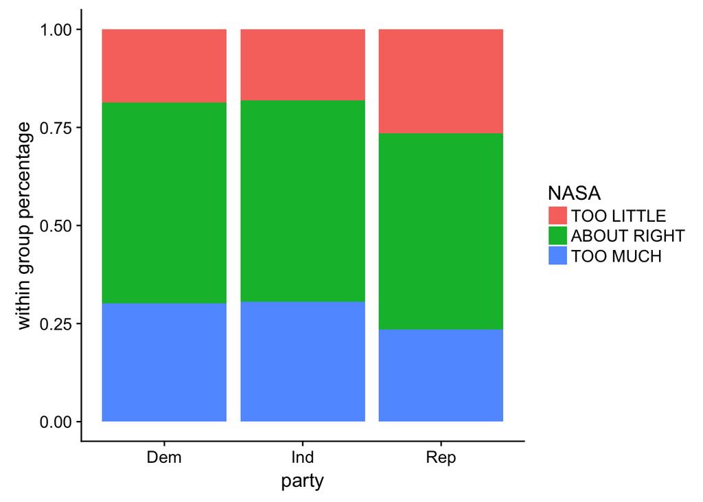

```r
gss %>%
  select(party, NASA) %>%
  ggplot(aes(x=party, fill = NASA)) +
  geom_bar(position = "fill") +
  ylab("within group percentage")
```

It doesn’t look like there’s much of a difference in how Democrats, Independents, and Republicans support space exploration, but let’s now drill down into this with some hypothesis testing, comparing Base R and `infer`.

What we essentially have is a contingency table of party affiliation and attitude towards space exploration, and we want to see if there’s a relationship between these variables. The Chi Squared Test of independence is used to determine if a significant relationship exists between two categorical variables, so we will use this test.

- Null hypothesis: There is no realationship between party (Democrat, Independent, Republican) and attitude towards space exploration (too little, about right, too much).
- Alternative hypothesis: There is a relationship between party and attitude towards space exploration.

Before we perform a Chi-squared test, in base R and `infer`, let’s quickly break down what a Chi-squared test is all about.

We have our data (party and attitude towards space exploration), we assume:

- **Assumption #1:** Variable are categorical. There are 3 types of categorical data:
  - *Dichotomous*: 2 groups (eg - Male and Female)
  - *Nominal*: 3 or more categorical groups (eg - undergrad, professor, graduate student, postdoctoral scholar)
  - *Ordinal*: ordered groups (eg - Pain Level 1, Pain Level 2, Pain Level 3, …)
- **Assumption #2:** Observations are independent of one another (eg - no relationship between any of the cases).
- **Assumption #3:** Categorical variable groupings must be mutually exclusive. In other words, we can’t have one participant as “Democrat” and “Independent”.
- **Assumption #4:** There must be at least 5 expected frequencies in each group of your categorical variable.

We meet those assumptions, so let’s power ahead!

There are two main ways to solve this problem:

1. Analytically (mathmematically)
2. Programatically

## Analytical Solution

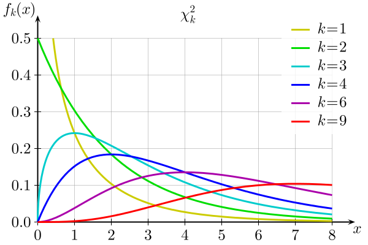

*Chi-squared probability density function (Wikipedia). k = degrees of freedom*

We assume the expected values follow a Chi-squared distribution, with a probability density function that depends on the degrees of freedom. The plot above shows how the distribution varies with the degrees of freedom (*k*). On the x axis is the Chi-squared statistic, which we can calculate in R. We could then see where it falls in the distribution, and observe the probability of arriving at that combination of variables, or a more extreme example. As our Chi-squared test statistic increases, we move further along the x axis to the right. There is less area under the curve to the right, and our p-value (the area under the curve to the right of the observed statistic) decreases.

Generally speaking, a larger Chi-squared statistic suggests stronger evidence for rejecting our null hhypothesis. If we observe a p-value <= .05, we would reject our null hypothesis.

What would it mean to accept our alternative hypothesis?

In the case of our example, if we we lived in a completely random universe, less than 5% of the time we would arrive at the particular combination of *party* and *attitude towards space exporlation* we observe in our data. In other words, the relationship between *party* and *attitude towards space exploration* we see in our data is **significant**.

**But is there actually a significant relationship between these variables? We will calculate a Chi-squared statistic for our data to find out.**

Base R’s `stats` package has a function that takes two vectors of data, and returns a Chi-squared test statistic, degrees of freedom, and p-value. Let’s save this observed Chi statistic for later use.

```r
chisq.test(gss$party, gss$NASA)
```

```
##
##  Pearson's Chi-squared test
##
## data:  gss$party and gss$NASA
## X-squared = 1.3261, df = 4, p-value = 0.8569
```

```r
observed_stat <- chisq.test(gss$party, gss$NASA)$stat
```

We might be tempted to look at this and say, there’s a high p-value. No significant relationship exists. Job done. This is what we expected looking at the bar plots earlier. But let’s go a step further with `infer`.

## Programatic Solution

Another way to test if there is a significant relationship in our data is to take a programatic approach.

In his talk, Andrew Bray says:

> If we live in world where variables are totally unrelated, the ties between variables are arbitrary, so they might just as well have been shuffled.

What would that random world look like? Let’s take one of the columns of our data_frame and scramble it.

```r
gss %>% select(party, NASA) %>%
  mutate(permutation_1 = sample(NASA),
         permutation_2 = sample(NASA))
```

```
## # A tibble: 149 x 4
##     party        NASA permutation_1 permutation_2
##    <fctr>      <fctr>        <fctr>        <fctr>
##  1    Ind  TOO LITTLE   ABOUT RIGHT   ABOUT RIGHT
##  2    Ind ABOUT RIGHT   ABOUT RIGHT      TOO MUCH
##  3    Dem ABOUT RIGHT      TOO MUCH      TOO MUCH
##  4    Ind  TOO LITTLE   ABOUT RIGHT    TOO LITTLE
##  5    Ind    TOO MUCH   ABOUT RIGHT    TOO LITTLE
##  6    Ind  TOO LITTLE   ABOUT RIGHT      TOO MUCH
##  7    Ind ABOUT RIGHT   ABOUT RIGHT   ABOUT RIGHT
##  8    Dem ABOUT RIGHT   ABOUT RIGHT   ABOUT RIGHT
##  9    Dem  TOO LITTLE      TOO MUCH      TOO MUCH
## 10    Ind  TOO LITTLE      TOO MUCH    TOO LITTLE
## # ... with 139 more rows
```

These premutations represent what we would expect to see **if the relationship between variables was completeley random**. We could generate many, many permuations, calcualte an Chi-squared statistic for each, and we would expect their distribution to approach the density functions shown above. Then we could plot our data on that distribution and see where it fell. If the area under the curve to the right of the point was less than 5%, we could reject the null hypothesis.

Infer makes this programatic approach very simple.

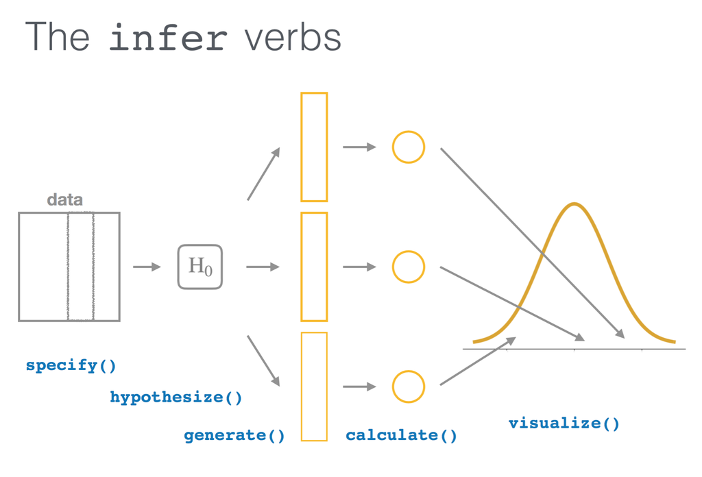

*A slide from Andrew Bray’s presentation.*

**Main Verbs:**

- `specify()` is like `dplyr::select()`: choose the variables from your df to test
- `hypothesize()` is where we select the null hypothesis
- `generate()` creates permutated values
- `calculate()` lets you choose what test statistic to calculate
- `visualize()` automatically plots permutated with ggplot, making it easy to add geoms onto it

**Highlights:**

- dataframe in dataframe out
- compose tests with pipes
- reading an inferential chain describes an inferential procedure

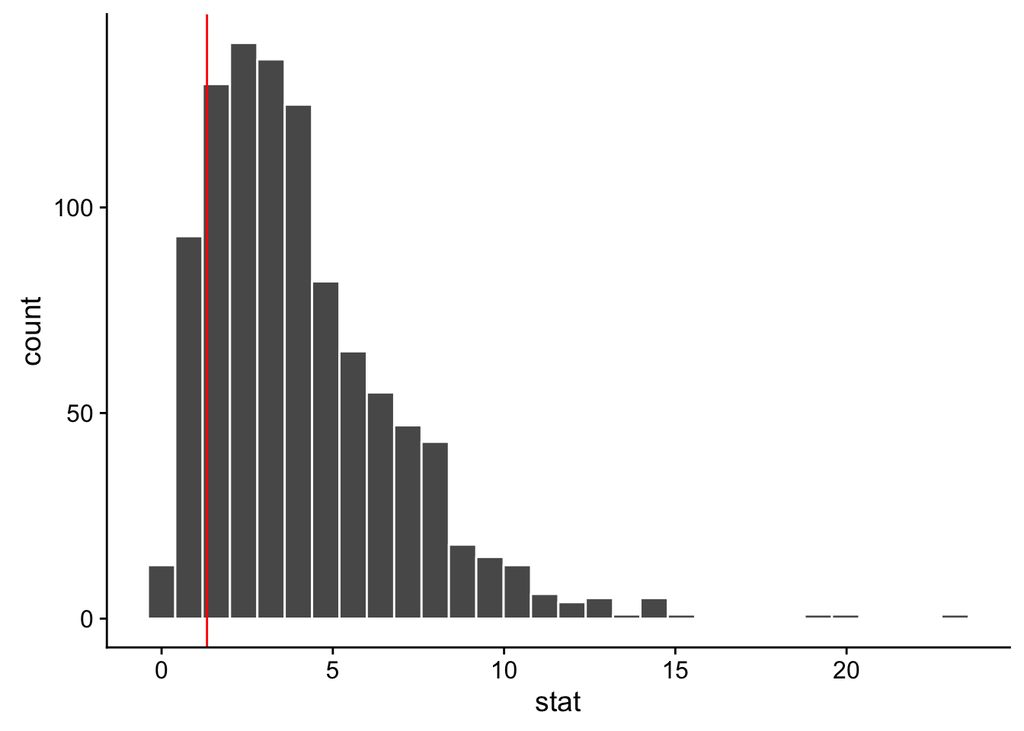

```r
gss %>%
  specify(NASA ~ party)  %>%
  hypothesize(null = "independence") %>%
  generate(reps = 1000, type = "permute") %>%
  calculate(stat = "Chisq") %>%
  visualize() +
  geom_vline(aes(xintercept = observed_stat), color = "red") # add a vertical line for gss data
```

If we wanted to get a p-value from this programatic appraoch, we can calculate the area uner the curve to the right of the observed statistic.

```r
gss %>%
  specify(NASA ~ party)  %>%
  hypothesize(null = "independence") %>%
  generate(reps = 1000, type = "permute") %>%
  calculate(stat = "Chisq") %>%
  summarise(p_val = mean(stat > observed_stat))
```

```
## # A tibble: 1 x 1
##   p_val
##   <dbl>
## 1 0.867
```

If we omit `visualize`, we get a dataframe of the permuted values:

```r
gss %>%
  specify(NASA ~ party)  %>%
  hypothesize(null = "independence") %>%
  generate(reps = 1000, type = "permute") %>%
  calculate(stat = "Chisq") #%>%
```

```
## # A tibble: 1,000 x 2
##    replicate      stat
##       <fctr>     <dbl>
##  1         1 5.9086476
##  2         2 0.7367260
##  3         3 2.4984952
##  4         4 9.9134319
##  5         5 8.8245055
##  6         6 1.9990705
##  7         7 2.0791010
##  8         8 0.3683407
##  9         9 3.5317742
## 10        10 2.8909804
## # ... with 990 more rows
```

```r
  # visualize() +
  # geom_vline(aes(xintercept = observed_stat), color = "red") # add a vertical line for gss data
```

If we omit `hypothesize`, we can bootstrap samples from our data.

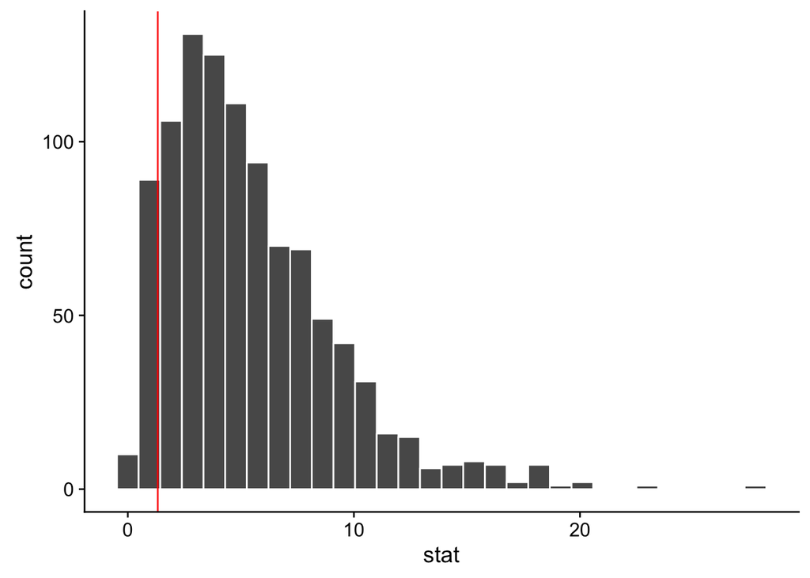

```r
gss %>%
  specify(NASA ~ party)  %>%
  #hypothesize(null = "independence") %>%
  generate(reps = 1000, type = "bootstrap") %>%
  calculate(stat = "Chisq") %>%
  visualize() +
  geom_vline(aes(xintercept = observed_stat), color = "red")
```

## Reusable Parts

One of the key features of `infer`, is that the functions therein are reusable. To illustrate, let’s consider our data. Let’s say we wanted to look at the differences between men and women in their reported level of happiness. We could observe this with a simple bar plot.

This is sample from a population, and there’s going to be some uncertainty associated with that sample. We can bound the uncertainty by adding **confidence intervals**, and accomplish this with reusable `infer` verbs.

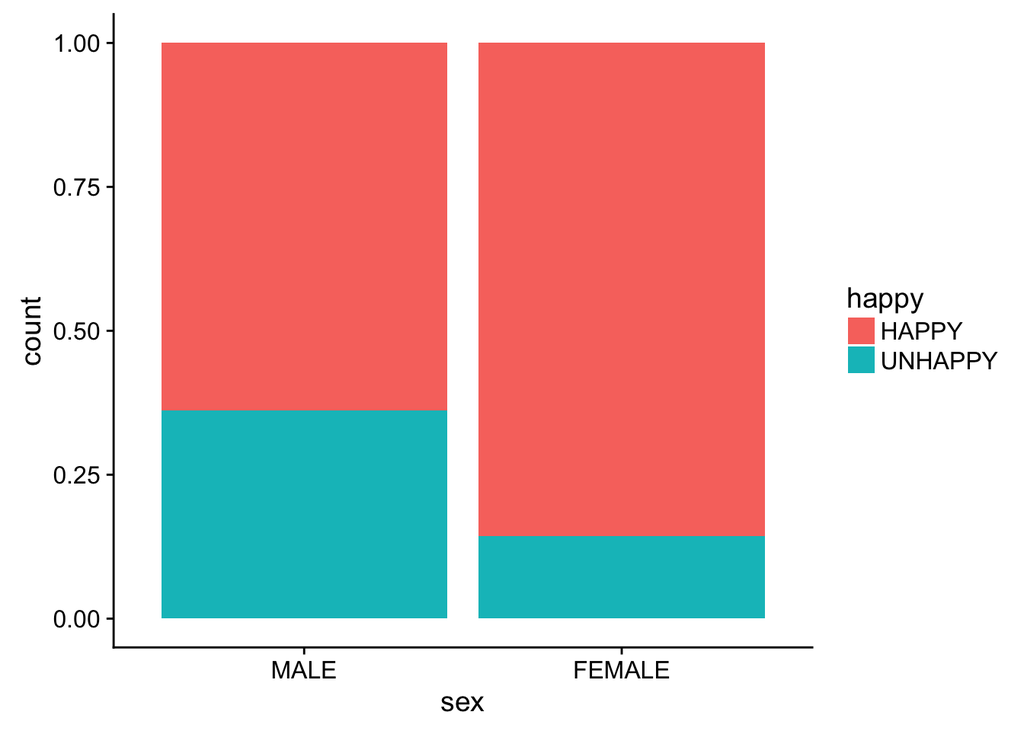

```r
gss %>% select(sex, happy) %>%
  ggplot() +
  geom_bar(aes(x = sex, fill = happy), position = "fill")
```

We could go on to measure the difference between male and female happiness by looking at the difference in the proportion of respondents claiming to be “Happy” or “Unhappy”. Let’s save these proportions for plotting later.

```r
gss %>% select(sex, happy) %>%
  group_by(sex, happy) %>%
  summarise(n = n()) %>%
  mutate(prop = n / sum(n)) -> gss_prop
gss_prop
```

```
## # A tibble: 4 x 4
## # Groups:   sex [2]
##      sex   happy     n      prop
##   <fctr>  <fctr> <int>     <dbl>
## 1   MALE   HAPPY    37 0.6379310
## 2   MALE UNHAPPY    21 0.3620690
## 3 FEMALE   HAPPY    78 0.8571429
## 4 FEMALE UNHAPPY    13 0.1428571
```

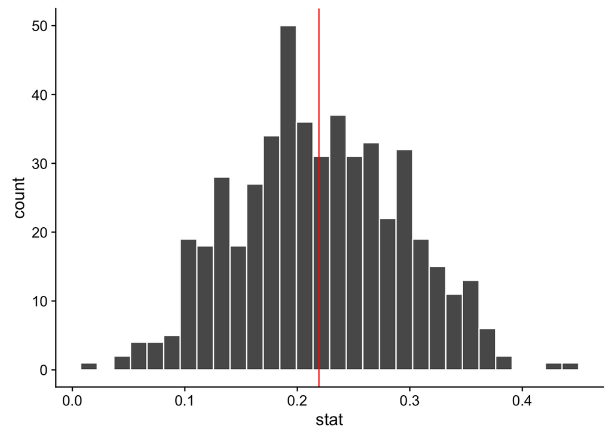

```r
obs_stat <- gss %>% # p_female - p_male
  group_by(sex) %>%
  summarize(p = mean(happy == "HAPPY")) %>%
  summarize(diff(p)) %>%
  pull()

boot <- gss %>%
  specify(happy ~ sex, success = "HAPPY") %>%
  generate(reps = 500, type = "bootstrap") %>%
  calculate(stat = "diff in props", order = c("FEMALE", "MALE"))

visualize(boot) +
  geom_vline(aes(xintercept = obs_stat), color = "red")
```

We can easily calculate the standard error (SD) of the distribution of bootstrapped samples, and then formulate confidence intervals.

95.45% of a normal population lies between two standard deviations below and above the mean. If we take the more memorbale *‘2’ standard errors* (compared to the less memorable ‘1.96’) above and below our sample statistic, we enclose 95% of the population.

```r
SE <- boot %>%
  summarize(sd(stat)) %>%
  pull()

SE
```

```
## [1] 0.07323895
```

```r
CI <- c(obs_stat - 2 * SE, obs_stat + 2 * SE)

CI
```

```
## [1] 0.07273392 0.36568972
```

And now we can add these confidence intervals to our etimate of the measured difference in happiness between men and women in our population with `geom_segment`.

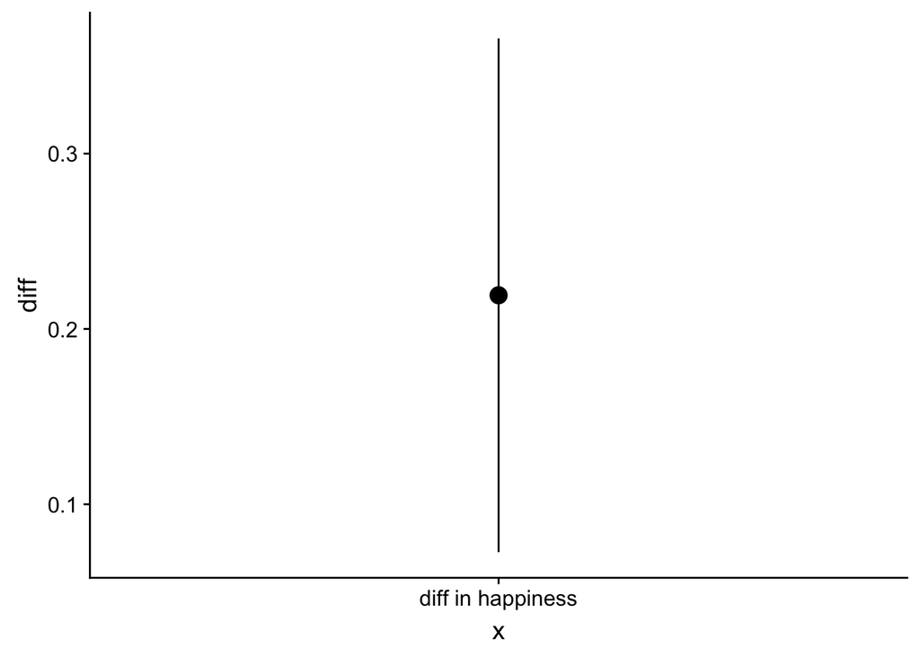

```r
x_pos <- "diff in happiness"

data_frame(diff = obs_stat) %>%
  mutate(x = x_pos) %>%
  ggplot() +
  geom_point(aes(x = x, y = diff), stat="identity", size = 4) +
  geom_segment(aes(x = x_pos, xend = x_pos, y = CI[1], yend = CI[2]))
```

Et voila. Confidence intervals made easy via bootstrapping in `infer`.

[figure not shown]

The joy of using infer for tidy hypothesis testing

## Conclusion

Two things stand out to me about `infer`. One if that it makes me think through the steps of what I’m doing, and the verbs in `infer` are reusable. Two, I save time because everything happens in a tidy way that plays well with `dplyr`. This makes it easy to hypothesis test, mutate and summarise new variables, pipe results into a `ggplot`, and overall spend less time working with lists and other data structures that I wrestle with in base R.

I look forward to seeing what’s down the line from `infer`. It seems like a powerful and concise way to perform statistical inference, and hypothesis test. Thanks to Andrew Bray for the excellent talk, and the developers of `infer` for working on tidy and expressive statistical inference.